# Do modelo de negócio ao pitch

Oficina de Pitch Canvas · Empreendedorismo Tecnológico e Desenvolvimento Territorial

Prof. Dr. Luiz Diego Vidal Santos

## Abertura Objetivo e resultado da oficina

Objetivo da oficina Transformar modelo em mensagem clara

Estruturar uma apresentação curta, compreensível e fundamentada a partir da lógica de valor do negócio, conectando o quadro conceitual à fala de três minutos.

Quadro preenchido Pitch de 3 minutos Plano de validação

Esta oficina complementa os nove blocos trabalhados na **Aula 09**, traduzindo estratégia em evidência e pedido objetivo.

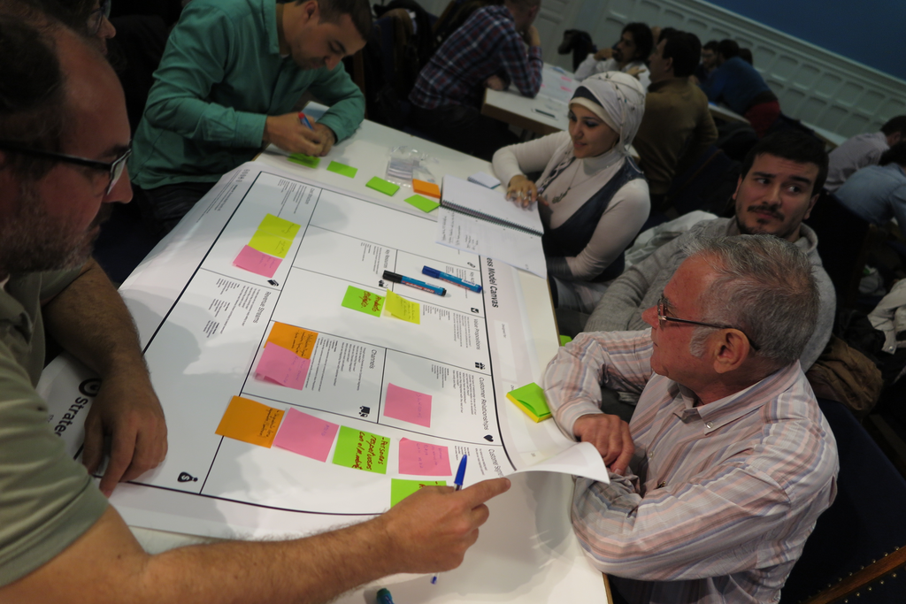

Participantes de oficina trabalhando em um Business Model Canvas.

Trabalho colaborativo com Business Model Canvas US Embassy Madrid, 2016 · CC BY 2.0 · exibição recortada

# Do modelo à mensagem

## Preparação Canvas e pitch cumprem funções diferentes

01 · Modelo Arquitetura de valor

Organiza internamente como o empreendimento cria, entrega e captura valor com recursos, canais e parceiros.

02 · Pitch Comunicação estratégica

Sintetiza problema, oportunidade e evidências em poucos minutos para pedir uma ação ou parceria concreta.

03 · Validação Teste empírico

Confronta suposições de mercado, preço e adoção com entrevistas de campo e protótipos reais.

O quadro de pitch organiza a narrativa da apresentação. Os oito blocos desta oficina compõem uma adaptação didática do Canvas.

## Preparação Comece pelo problema e pelo contexto

01 Quem?

Pessoa, grupo ou organização afetada.

02 Onde?

Situação concreta e recorte territorial.

03 Qual dificuldade?

Custo, perda ou gargalo percebido.

04 Como resolve?

Alternativa atual e suas limitações.

**Pergunta de partida:** que evidência observável indica que esse problema realmente importa para o público escolhido?

Nota pedagógica: na aula de referência (Márcia May, 2023), proposta de valor, clientes e receitas iniciam o percurso, articulados aos demais blocos.

## Preparação Defina a pessoa e o contexto territorial

Recorte inicial Primeiro segmento prioritário

Considere atividade econômica, território, condições reais de uso, rotinas operacionais e capacidade de decisão ou pagamento.

Exemplo didático Associações rurais no semiárido

Associação de produtores familiares que precisa monitorar a umidade do solo em áreas com conexão intermitente à internet.

**Atenção analítica:** cliente, usuário, beneficiário e pagador nem sempre são a mesma pessoa no território.

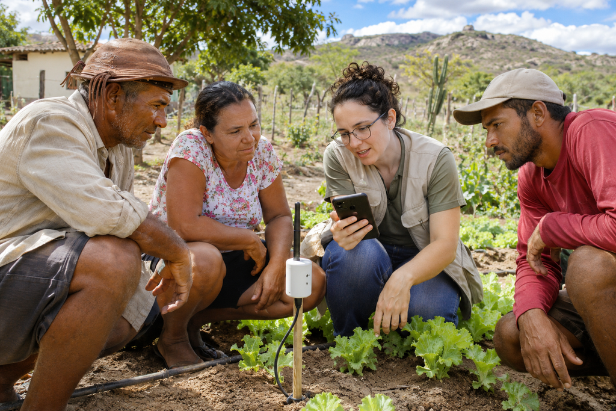

Produtores e pesquisadora examinando um sensor de solo em campo.

Validação em ambiente real de cultivo Imagem ilustrativa gerada por IA para contextualização da oficina

## Preparação Proposta de valor em uma frase

**Para** [segmento definido] · **que enfrenta** [problema específico e mensurável]

**Oferecemos** [solução tecnológica ou serviço] · **que permite** [benefício concreto no uso]

**Nossa diferença:** [atributo verificável frente às alternativas existentes]

Critério 1 Compreensão imediata

Um interlocutor fora da equipe entende a frase em uma leitura?

Critério 2 Relevância real

O benefício resolve uma dor prioritária ou apenas desejável?

Critério 3 Comparação justa

O atributo declarado supera o que o público já utiliza hoje?

## Preparação Uma fala curta começa com clareza

Estrutura de elevador Sequência lógica em 4 passos

**01 · Quem?** Público recortado no território.

**02 · Problema?** Dificuldade concreta enfrentada.

**03 · Solução?** Oferta objetiva sem jargão técnico.

**04 · Benefício?** Ganho prático para quem decide.

Explique o projeto como quem conversa com um parceiro interessado que ainda não conhece sua área técnica.

[figure not shown]

Apresentador fala em uma oficina de Business Model Canvas.

Comunicação objetiva em oficina de empreendedorismo US Embassy Madrid, 2016 · CC BY 2.0 · exibição recortada

## Preparação Um exemplo para transformar em pitch

Caso da aula de referência O berço que virou estante

Para ilustrar como traduzir um produto em proposta clara, a professora parte de um móvel infantil reaproveitado após o crescimento da criança.

**Público inicial:** famílias com móveis infantis parados que buscam mobília funcional para novas fases.

Hipóteses derivadas Da ideia à verificação

**Proposta declarada:** transformar o berço original em estante modular aproveitando a estrutura existente.

**Pontos a investigar:** interesse real das famílias, custo de adaptação, logística de retirada ou entrega e disposição a pagar.

Benefício anunciado antes do contato com potenciais usuários é sempre **hipótese**, jamais fato comprovado.

# Construção do quadro

## Pitch Canvas Como o Canvas é usado em uma oficina

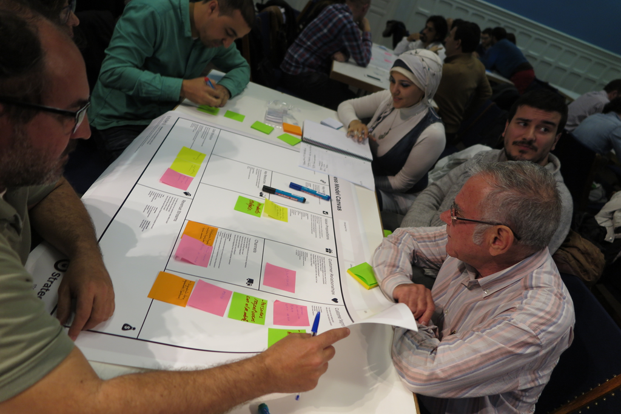

Participantes discutem um Business Model Canvas com notas adesivas.

Construção iterativa com notas adesivas US Embassy Madrid, 2016 · CC BY 2.0 · exibição recortada

### Dinâmica de construção

**01 · Escrever:** registre uma ideia objetiva por cartão ou nota adesiva.

**02 · Agrupar:** posicione cada nota no bloco correspondente da lógica de valor.

**03 · Discutir:** identifique lacunas, suposições ocultas e vínculos entre blocos.

**04 · Revisar:** ajuste o quadro após ouvir potenciais usuários ou mentores.

## Pitch Canvas Um Canvas preenchido: YouTube

[figure not shown]

Esboço do Business Model Canvas do YouTube, com usuários, audiência e anunciantes.

Esboço histórico didático (Osterwalder, 2010) CC BY 2.0 · imagem original sem alteração

### Leitura rápida

**Públicos:** plataforma multilateral unindo criadores de vídeo, audiência e anunciantes.

**Valor entregue:** hospedagem e alcance gratuito ao usuário; visibilidade segmentada ao anunciante.

**Receita no esboço:** publicidade sustenta a infraestrutura sem cobrar do espectador.

Retrato conceitual de época, utilizado para compreender lógica de blocos, sem descrever o portfólio atual completo da empresa.

## Pitch Canvas Quadro de pitch da oficina (8 blocos)

01 · Público e problema Dor prioritária

Quem enfrenta qual dificuldade relevante?

02 · Solução e valor Oferta prática

O que oferecemos e com qual benefício mensurável?

03 · Diferencial Alternativas

Que opções existem hoje e onde superamos?

04 · Mercado Entrada territorial

Qual segmento alcançaremos primeiro?

05 · Receita Captura de valor

Quem paga, pelo quê e em qual frequência?

06 · Evidências Fatos vs. hipóteses

O que já testamos e o que falta comprovar?

07 · Equipe Capacidade

Quem executa e qual é o próximo marco?

08 · Pedido Próxima ação

Que apoio específico buscamos ao final?

Os blocos 01 a 04 explicam a **oportunidade**; os blocos 05 a 08 demonstram **viabilidade, tração e propósito da conversa**.

## Pitch Canvas Exemplo preenchido: irrigação rural

01 · Público e problema Irrigação comunitária

Associações rurais precisam decidir quando e quanto irrigar.

02 · Solução e valor Monitoramento

Sensores de solo e alertas simples para apoiar a decisão.

03 · Diferencial Conectividade rural

Operação proposta mesmo sob conexão intermitente.

04 · Mercado Foco inicial

Primeiras associações de um território rural delimitado.

05 · Receita Modelo a validar

Assinatura pelo serviço de monitoramento (hipótese).

06 · Evidências Estágio atual

Entrevistas iniciais e protótipo de bancada a testar em campo.

07 · Equipe Competências

Manejo agrícola integrado a hardware e dados ambientais.

08 · Pedido Parceria piloto

Abertura de associação parceira para entrevistas e teste de uso.

Caso fictício formulado para a oficina. Benefícios operacionais, dimensionamento de mercado e disposição a pagar permanecem como hipóteses para validação.

## Pitch Canvas 1 · Público e problema

Recorte Quem?

Qual segmento específico sofre primeiro com o problema e possui urgência de resolução?

Evidência Qual problema?

Em que momento do dia ou da safra o problema ocorre e qual consequência financeira ou produtiva gera?

Linha de base Alternativa atual

Como as pessoas contornam a falha hoje, quanto gastam e por que continuam insatisfeitas?

**Teste prático em campo:** peça aos entrevistados que descrevam exemplos concretos da última semana ou da última safra, evitando opiniões genéricas.

## Pitch Canvas 2 · Solução, benefício e diferencial

**Solução:** qual artefato físico, software ou serviço técnico colocamos nas mãos do usuário?

**Benefício:** que mudança verificável o uso produz em custo, tempo, produtividade ou segurança hídrica?

**Diferencial:** qual barreira técnica ou adaptação territorial impede que soluções tradicionais façam o mesmo?

Ilustração territorial Conexão intermitente

Sensores com armazenamento local e envio por janela de sinal evitam perda de dados na propriedade rural.

Regra de ouro Não prometer além do testado

Enquanto não houver ensaio de campo, apresente o ganho esperado como **meta técnica**, não como economia garantida.

## Pitch Canvas 3 · Mercado e receita

Foco inicial Mercado acessível

Quem podemos alcançar primeiro com a equipe, canais e recursos disponíveis neste semestre?

Captura de valor Fonte de receita

Quem paga, por qual unidade de entrega (equipamento, assinatura ou licenciamento) e com que periodicidade?

Transparência Lastro das premissas

Quais números vieram de censos, editais ou entrevistas e quais são estimativas iniciais?

Bancas avaliadoras confiam em estimativas conservadoras e bem fundamentadas muito mais do que em projeções bilionárias sem memória de cálculo.

## Pitch Canvas Do público à estimativa inicial

01 · Delimitar Universo elegível

Defina território e perfil do cliente para contar quantas organizações atendem aos critérios.

02 · Estimar Alcance e adesão

Estabeleça uma parcela realista de contato no período e uma taxa plausível de conversão piloto.

03 · Testar Confrontar dados

Documente fontes e hipóteses para revisar os percentuais após as primeiras abordagens reais.

**Exemplo didático de cálculo:** 40 associações elegíveis × 25% alcançadas no trimestre × 20% de adesão hipotética = **2 clientes piloto** no período. Nenhum percentual acima é dado observado.

## Pitch Canvas Canal, relacionamento e receita

Acesso e entrega Canal

Como as pessoas conhecem, testam e recebem a oferta? Exemplo: parceria com associações locais, sindicatos e demonstração técnica em propriedade-piloto.

Continuidade Relacionamento

Como a equipe acompanha, treina e mantém o usuário? Exemplo: suporte pós-instalação e visitas periódicas de calibração.

Sustentabilidade Modelo de receita

Quem paga, pelo quê e como? Venda única de hardware, taxa recorrente de manutenção ou contrato institucional público constituem hipóteses distintas a testar.

Cada canal prometido gera exigências diretas sobre equipe, transporte e estrutura de custos. Evite assumir canais ou receitas como fatos antes do teste.

## Pitch Canvas O dinheiro entra depois da despesa?

01 · Antes Desembolso inicial

Adquirir componentes, montar protótipos, deslocar equipe e adaptar materiais para instalação.

02 · Durante Operação e entrega

Executar a instalação em campo, capacitar os usuários e arcar com suporte e manutenção.

03 · Depois Recebimento

Faturar e receber pelo serviço ou equipamento apenas após a entrega validada ou fechamento do ciclo.

**Atenção ao capital de giro:** quando despesas antecedem o recebimento, o modelo precisa prever fonte de financiamento ou cronograma de pagamento para atravessar o intervalo.

## Pitch Canvas 4 · Evidências, equipe e pedido

Comprovação Evidências

Separe com nitidez o que já foi medido em laboratório ou entrevistas daquilo que segue como hipótese.

Execução Equipe

Explicite quem domina a técnica e a operação, reconhecendo eventuais lacunas de competência a suprir.

Chamada à ação Pedido

Feche o pitch dizendo exatamente o que solicita ao interlocutor e qual passo ocorrerá na sequência.

Um bom pedido final evita termos vagos (“queremos apoio”) e especifica recursos, acesso a áreas de teste, mentoria ou parceria institucional.

## Pitch Canvas Coerência e consistência

Critério estrutural Coerência entre escolhas

Se a proposta promete atendimento presencial frequente na zona rural, os blocos de equipe, tempo e custos precisam contemplar veículos, diárias e pessoal compatíveis.

Critério analítico Consistência das afirmações

Toda estimativa de mercado ou ganho técnico exige fonte, recorte geográfico, período e premissas explícitas. Projeção financeira não é faturamento realizado.

Na síntese da aula de referência (Márcia May, 2023), a harmonia entre os blocos do Canvas e a honestidade das premissas definem a qualidade da apresentação.

# Oficina guiada

## Oficina Caso integrador: irrigação no território

Cenário de estudo Sensores em áreas comunitárias

Sistema de sensores e alertas de umidade para apoiar decisões cotidianas de irrigação em associações rurais com conectividade limitada.

Trabalho em grupo Preenchimento e triagem

Escolham um território real conhecido pela equipe, preencham os 8 blocos do quadro de pitch e marquem em cores distintas **fatos observados** e **hipóteses a testar**.

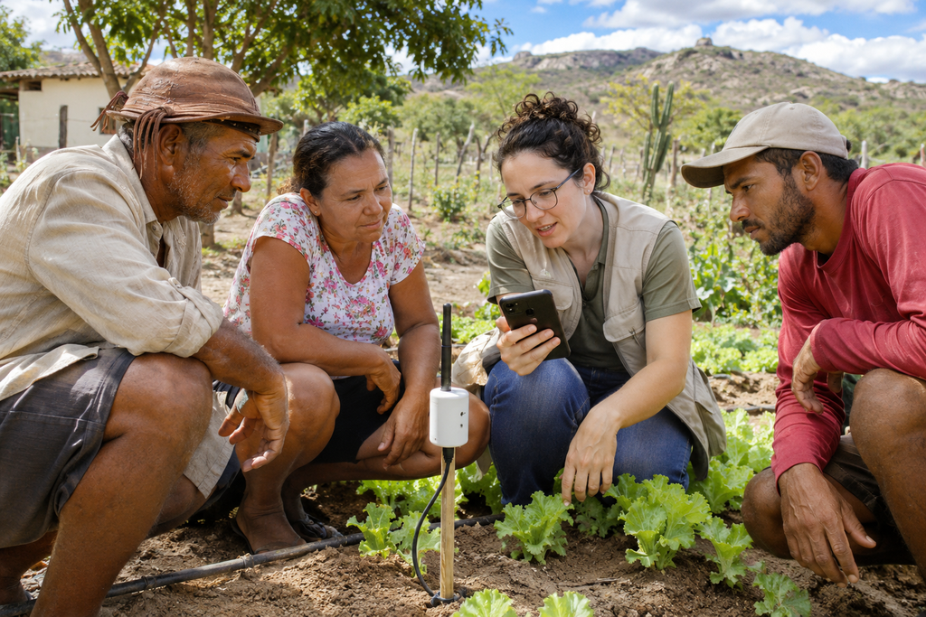

Exemplo ilustrativo de produtores avaliando sensor no campo.

Contexto territorial da prática em campo Caso fictício ilustrativo · imagem gerada por IA para fins didáticos

## Oficina Roteiro para três minutos

0:00 – 0:30

**01 · Público e problema:** quem enfrenta a dificuldade, onde e com qual perda concreta.

0:30 – 1:05

**02 · Solução e valor:** o que o produto ou serviço entrega na rotina de uso.

1:05 – 1:35

**03 · Diferencial:** contraste objetivo frente às alternativas atuais no território.

1:35 – 2:05

**04 · Mercado e receita:** foco inicial de entrada e lógica prevista de pagamento.

2:05 – 2:40

**05 · Evidências e equipe:** o que já foi validado e competências para executar.

2:40 – 3:00

**06 · Pedido:** convite concreto para o próximo passo após a apresentação.

Os tempos por bloco orientam o ensaio da equipe e podem ser ajustados ao regulamento de cada banca, edital de fomento ou desafio de inovação.

## Oficina Do quadro à fala: exemplo curto

“Associações rurais precisam decidir diariamente quando irrigar suas lavouras sem desperdício de água e energia. Desenvolvemos sensores e alertas locais adaptados a áreas com conexão intermitente. Nesta primeira etapa, validamos o protótipo em bancada e buscamos uma associação parceira para realizar testes em campo e entrevistas com irrigantes.”

01 · Abertura Público + dor

Define quem decide e qual problema enfrenta.

02 · Oferta Solução

Apresenta resposta adaptada ao contexto rural.

03 · Estágio Evidências

Situa com transparência o nível de maturidade.

04 · Fechamento Pedido

Convoca parceria para teste de campo.

Na apresentação completa de 3 minutos, a equipe acrescenta alternativas existentes, estimativa inicial de mercado e modelo de receita previsto.

## Oficina Dinâmica: preencher, apresentar e revisar

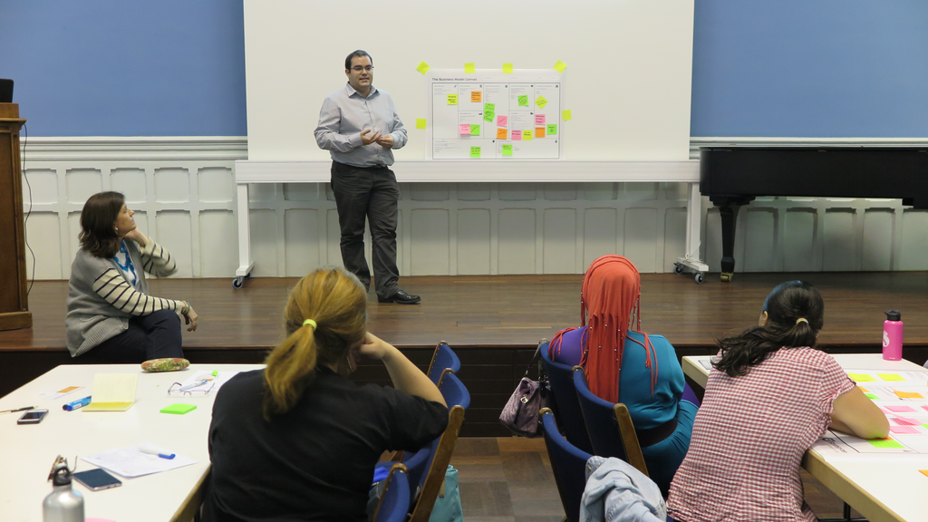

Pessoas acompanham a apresentação de um quadro Canvas preenchido em oficina.

Apresentação e crítica coletiva entre equipes US Embassy Madrid, 2016 · CC BY 2.0 · exibição recortada

**20 min · Preencher o quadro:** consolidar os 8 blocos distinguindo dados de suposições.

**15 min · Preparar a fala:** distribuir os tempos entre os blocos em roteiro de 3 minutos.

**03 min · Apresentar por equipe:** exposição cronometrada para os colegas e docência.

**05 min · Receber perguntas:** registrar objeções sobre usuário, custos ou logística.

**15 min · Revisar e escolher um teste:** transformar a principal dúvida em plano de verificação.

## Oficina Perguntas para avaliar o pitch

**01 · Clareza de público e dor:** ficou inequívoco quem enfrenta o problema, em que território atua e por que o tema importa?

**02 · Valor e alternativas:** a solução entrega um benefício compreensível e explicita como supera as práticas atuais?

**03 · Evidência vs. suposição:** a exposição separa fatos já verificados em campo de hipóteses que ainda aguardam teste?

**04 · Coerência financeira e pedido:** modelo de receita, custos operacionais e pedido final correspondem ao estágio atual do projeto?

**Regra de devolutiva entre pares:** após cada pitch, aponte um ponto muito claro, uma dúvida central de negócio e uma sugestão prática de teste em campo.

## Oficina Rubrica de avaliação da oficina

| Critério | Pergunta orientadora | Pontos |
| --- | --- | --- |
| Problema e público | São específicos, contextualizados e compreensíveis? | 2 |
| Solução e diferencial | Respondem diretamente à dor e consideram alternativas? | 2 |
| Modelo e coerência | Receita, canais e custos sustentam o que foi prometido? | 2 |
| Evidências e validação | A equipe distingue fatos de hipóteses e propõe teste? | 2 |
| Apresentação e pedido | A mensagem tem clareza temporal e o pedido é concreto? | 2 |
| **Total da atividade** | **Critério adaptável às entregas parciais da disciplina** | **10** |

Avalie menos pela sofisticação estética de protótipos futuros e mais pela **consistência entre evidência, cliente e modelo de entrega**.

## Oficina Da objeção recebida ao plano de teste

01 · Hipótese prioritária O que precisa ser verdade?

Associações locais valorizam e conseguem operar alertas de irrigação com conexão intermitente.

02 · Experimento enxuto Como testar sem construir tudo?

Entrevistar representantes, observar decisões atuais e demonstrar protótipo simples em tela ou bancada.

03 · Registro e critério Como decidir após o teste?

Anotar perfil dos entrevistados, respostas literais e definir de antemão qual evidência força o ajuste do modelo.

Uma objeção dura recebida durante a oficina é valiosa porque revela antes da fase de custos exatamente qual hipótese merece ser testada primeiro.

## Oficina Entrega e continuidade com a disciplina

Produtos entregáveis Pacote desta oficina

1. Quadro de pitch (8 blocos) preenchido pela equipe.
2. Roteiro estruturado para fala de 3 minutos.
3. Ficha de validação com hipótese crítica, público-alvo, método de teste, critério de decisão e próximo passo.

Articulação teórica Retorno à Aula 09

Na sequência do semestre, contraste o pitch validado com os **nove blocos completos** da Aula 09 para checar parceiros-chave, atividades críticas e estrutura de custos antes do plano de negócio.

Pitch, Business Model Canvas e ciclo *Construir–Medir–Aprender* formam uma engrenagem contínua entre ideia tecnológica e adoção territorial.

## Oficina Da apresentação à construção do negócio

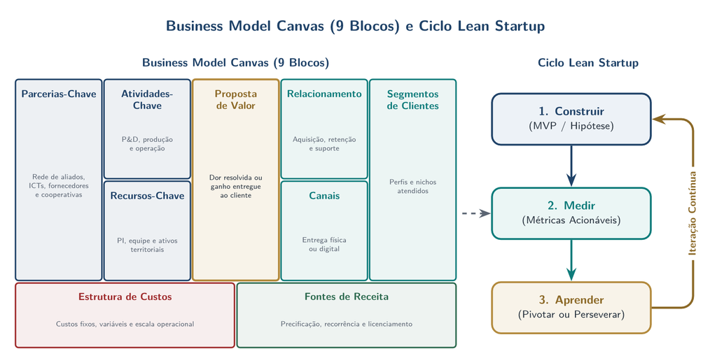

Nove blocos do Business Model Canvas e ciclo de validação construir, medir e aprender.

Integração entre Business Model Canvas e ciclo Lean Startup Arquitetura de criação, entrega e captura de valor vinculada ao ciclo Construir–Medir–Aprender

O pitch sintetiza a oportunidade e convoca parceiros; a Aula 09 e os módulos seguintes aprofundam a arquitetura econômica e territorial do negócio.

## Referências Referência e nota de uso didático

Fonte audiovisual de base Aula de referência

MAY, Márcia. [*Como criar um pitch/Canvas*](https://www.youtube.com/watch?v=Dd2KHaPnPGA). Inovação e Desenvolvimento Territorial UFPR, 2023.

Os oito blocos do quadro de pitch, o caso fictício de irrigação rural, o roteiro de três minutos e a rubrica constituem adaptações didáticas próprias desta oficina.

Créditos e recursos extras Acervo e materiais

Fotografias de oficinas e esboço do YouTube com autores e licenças CC BY 2.0 indicados nos slides; imagem do sensor gerada por IA para fins ilustrativos.

Recursos adicionais: [Pitch PUMA, Sebrae](https://es.lojavirtualsebrae.com.br/loja/biblioteca-digital/393-pitch-puma) · [Exemplos de Canvas, Sebrae RS](https://conhecimento.sebraers.com.br/wp-content/uploads/2022/11/E-book-Tudo-sobre-o-Business-Model-Canvas.pdf) · [Pitch Canvas, Fernando Seabra](https://pt.scribd.com/document/739657745/ebook-Pitch-Canvas-Fernando-Seabra).